# Risk Factor Analysis

## Outcome Variable

**Outcome Variable:** whz

## Predictor Variables

**Intervention Variable:** exclfeed3

**Adjustment Set:**

unadjusted

## Stratifying Variables

The analysis was stratified on these variable(s):

- agecat
- studyid
- country

## Data Summary

| agecat | studyid | country | exclfeed3 | n_cell | n |
| --- | --- | --- | --- | --- | --- |
| Birth | ki0047075b-MAL-ED | BANGLADESH | 1 | 164 | 227 |
| Birth | ki0047075b-MAL-ED | BANGLADESH | 0 | 63 | 227 |
| Birth | ki0047075b-MAL-ED | BRAZIL | 1 | 65 | 177 |
| Birth | ki0047075b-MAL-ED | BRAZIL | 0 | 112 | 177 |
| Birth | ki0047075b-MAL-ED | INDIA | 1 | 121 | 193 |
| Birth | ki0047075b-MAL-ED | INDIA | 0 | 72 | 193 |
| Birth | ki0047075b-MAL-ED | NEPAL | 1 | 60 | 166 |
| Birth | ki0047075b-MAL-ED | NEPAL | 0 | 106 | 166 |
| Birth | ki0047075b-MAL-ED | PERU | 1 | 64 | 265 |
| Birth | ki0047075b-MAL-ED | PERU | 0 | 201 | 265 |
| Birth | ki0047075b-MAL-ED | SOUTH AFRICA | 1 | 32 | 231 |
| Birth | ki0047075b-MAL-ED | SOUTH AFRICA | 0 | 199 | 231 |
| Birth | ki0047075b-MAL-ED | TANZANIA, UNITED REPUBLIC OF | 1 | 38 | 114 |
| Birth | ki0047075b-MAL-ED | TANZANIA, UNITED REPUBLIC OF | 0 | 76 | 114 |
| Birth | ki1000108-CMC-V-BCS-2002 | INDIA | 1 | 4 | 4 |
| Birth | ki1000108-CMC-V-BCS-2002 | INDIA | 0 | 0 | 4 |
| Birth | ki1000108-IRC | INDIA | 1 | 0 | 9 |
| Birth | ki1000108-IRC | INDIA | 0 | 9 | 9 |
| Birth | ki1000109-EE | PAKISTAN | 1 | 1 | 1 |
| Birth | ki1000109-EE | PAKISTAN | 0 | 0 | 1 |
| Birth | ki1000304b-SAS-CompFeed | INDIA | 1 | 45 | 47 |
| Birth | ki1000304b-SAS-CompFeed | INDIA | 0 | 2 | 47 |
| Birth | ki1101329-Keneba | GAMBIA | 1 | 1150 | 1305 |
| Birth | ki1101329-Keneba | GAMBIA | 0 | 155 | 1305 |
| Birth | kiGH5241-JiVitA-3 | BANGLADESH | 1 | 13731 | 15136 |
| Birth | kiGH5241-JiVitA-3 | BANGLADESH | 0 | 1405 | 15136 |
| Birth | kiGH5241-JiVitA-4 | BANGLADESH | 1 | 28 | 31 |
| Birth | kiGH5241-JiVitA-4 | BANGLADESH | 0 | 3 | 31 |
| 6 months | ki0047075b-MAL-ED | BANGLADESH | 1 | 172 | 237 |
| 6 months | ki0047075b-MAL-ED | BANGLADESH | 0 | 65 | 237 |

[output cut: 58 more lines]

The following strata were considered:

- agecat: 24 months, studyid: ki0047075b-MAL-ED, country: BANGLADESH
- agecat: 24 months, studyid: ki0047075b-MAL-ED, country: BRAZIL
- agecat: 24 months, studyid: ki0047075b-MAL-ED, country: INDIA
- agecat: 24 months, studyid: ki0047075b-MAL-ED, country: NEPAL
- agecat: 24 months, studyid: ki0047075b-MAL-ED, country: PERU
- agecat: 24 months, studyid: ki0047075b-MAL-ED, country: SOUTH AFRICA
- agecat: 24 months, studyid: ki0047075b-MAL-ED, country: TANZANIA, UNITED REPUBLIC OF
- agecat: 24 months, studyid: ki1000108-CMC-V-BCS-2002, country: INDIA
- agecat: 24 months, studyid: ki1000108-IRC, country: INDIA
- agecat: 24 months, studyid: ki1017093b-PROVIDE, country: BANGLADESH
- agecat: 24 months, studyid: ki1101329-Keneba, country: GAMBIA
- agecat: 24 months, studyid: ki1113344-GMS-Nepal, country: NEPAL
- agecat: 24 months, studyid: kiGH5241-JiVitA-3, country: BANGLADESH
- agecat: 24 months, studyid: kiGH5241-JiVitA-4, country: BANGLADESH
- agecat: 6 months, studyid: ki0047075b-MAL-ED, country: BANGLADESH
- agecat: 6 months, studyid: ki0047075b-MAL-ED, country: BRAZIL
- agecat: 6 months, studyid: ki0047075b-MAL-ED, country: INDIA
- agecat: 6 months, studyid: ki0047075b-MAL-ED, country: NEPAL
- agecat: 6 months, studyid: ki0047075b-MAL-ED, country: PERU
- agecat: 6 months, studyid: ki0047075b-MAL-ED, country: SOUTH AFRICA
- agecat: 6 months, studyid: ki0047075b-MAL-ED, country: TANZANIA, UNITED REPUBLIC OF
- agecat: 6 months, studyid: ki1000108-CMC-V-BCS-2002, country: INDIA
- agecat: 6 months, studyid: ki1000108-IRC, country: INDIA
- agecat: 6 months, studyid: ki1000109-EE, country: PAKISTAN
- agecat: 6 months, studyid: ki1000304b-SAS-CompFeed, country: INDIA
- agecat: 6 months, studyid: ki1017093b-PROVIDE, country: BANGLADESH
- agecat: 6 months, studyid: ki1101329-Keneba, country: GAMBIA
- agecat: 6 months, studyid: ki1113344-GMS-Nepal, country: NEPAL
- agecat: 6 months, studyid: kiGH5241-JiVitA-3, country: BANGLADESH
- agecat: 6 months, studyid: kiGH5241-JiVitA-4, country: BANGLADESH
- agecat: Birth, studyid: ki0047075b-MAL-ED, country: BANGLADESH
- agecat: Birth, studyid: ki0047075b-MAL-ED, country: BRAZIL
- agecat: Birth, studyid: ki0047075b-MAL-ED, country: INDIA
- agecat: Birth, studyid: ki0047075b-MAL-ED, country: NEPAL
- agecat: Birth, studyid: ki0047075b-MAL-ED, country: PERU
- agecat: Birth, studyid: ki0047075b-MAL-ED, country: SOUTH AFRICA
- agecat: Birth, studyid: ki0047075b-MAL-ED, country: TANZANIA, UNITED REPUBLIC OF
- agecat: Birth, studyid: ki1000108-CMC-V-BCS-2002, country: INDIA
- agecat: Birth, studyid: ki1000108-IRC, country: INDIA
- agecat: Birth, studyid: ki1000109-EE, country: PAKISTAN
- agecat: Birth, studyid: ki1000304b-SAS-CompFeed, country: INDIA
- agecat: Birth, studyid: ki1101329-Keneba, country: GAMBIA
- agecat: Birth, studyid: kiGH5241-JiVitA-3, country: BANGLADESH
- agecat: Birth, studyid: kiGH5241-JiVitA-4, country: BANGLADESH

### Dropped Strata

Some strata were dropped due to rare outcomes:

- agecat: Birth, studyid: ki1000108-CMC-V-BCS-2002, country: INDIA
- agecat: Birth, studyid: ki1000108-IRC, country: INDIA
- agecat: Birth, studyid: ki1000109-EE, country: PAKISTAN
- agecat: Birth, studyid: ki1000304b-SAS-CompFeed, country: INDIA
- agecat: Birth, studyid: kiGH5241-JiVitA-4, country: BANGLADESH
- agecat: 6 months, studyid: ki1000108-CMC-V-BCS-2002, country: INDIA
- agecat: 6 months, studyid: ki1000108-IRC, country: INDIA
- agecat: 24 months, studyid: ki1000108-CMC-V-BCS-2002, country: INDIA
- agecat: 24 months, studyid: ki1000108-IRC, country: INDIA

## Methods Detail

We’re interested in the causal parameters $E[Y_a]$ for all values of $a \in \mathcal{A}$. These parameters represent the mean outcome if, possibly contrary to fact, we intervened to set all units to have $A=a$. Under the randomization and positivity assumptions, these are identified by the statistical parameters $\psi_a=E_W[E_{Y|A,W}(Y|A=a,W)]$. In addition, we’re interested in the mean of $Y$, $E[Y]$ under no intervention (the observed mean). We will estimate these parameters by using SuperLearner to fit the relevant likelihood factors – $E_{Y|A,W}(Y|A=a,W)$ and $p(A=a|W)$, and then updating our likelihood fit using a joint TMLE.

For unadjusted analyses ($W=\{\}$), initial likelihoods were estimated using Lrnr_glm to estimate the simple $E(Y|A)$ and Lrnr_mean to estimate $p(A)$. For adjusted analyses, a small library containing Lrnr_glmnet, Lrnr_xgboost, and Lrnr_mean was used.

Having estimated these parameters, we will then use the delta method to estimate relative risks and attributable risks relative to a prespecified baseline level of $A$.

# Results Detail

## Results Plots

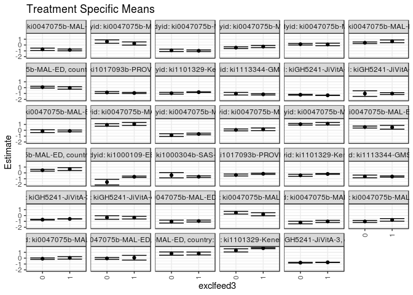

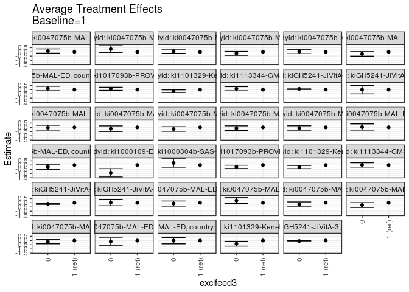

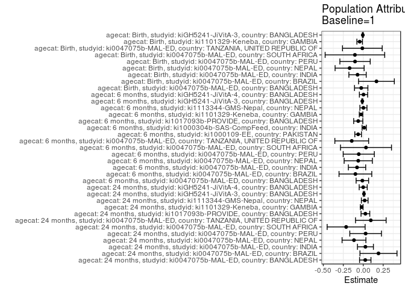

## Results Table

### Parameter: TSM

| agecat | studyid | country | intervention_level | baseline_level | estimate | ci_lower | ci_upper |
| --- | --- | --- | --- | --- | --- | --- | --- |
| Birth | ki0047075b-MAL-ED | BANGLADESH | 1 | NA | -0.9448171 | -1.1115593 | -0.7780749 |
| Birth | ki0047075b-MAL-ED | BANGLADESH | 0 | NA | -1.0361905 | -1.2865873 | -0.7857936 |
| Birth | ki0047075b-MAL-ED | BRAZIL | 1 | NA | 0.2180000 | -0.0472800 | 0.4832800 |
| Birth | ki0047075b-MAL-ED | BRAZIL | 0 | NA | 0.4799107 | 0.2467706 | 0.7130509 |
| Birth | ki0047075b-MAL-ED | INDIA | 1 | NA | -1.0111570 | -1.1972827 | -0.8250314 |
| Birth | ki0047075b-MAL-ED | INDIA | 0 | NA | -1.2022222 | -1.4235655 | -0.9808790 |
| Birth | ki0047075b-MAL-ED | NEPAL | 1 | NA | -0.7478333 | -0.9693203 | -0.5263464 |
| Birth | ki0047075b-MAL-ED | NEPAL | 0 | NA | -1.0150000 | -1.1917907 | -0.8382093 |
| Birth | ki0047075b-MAL-ED | PERU | 1 | NA | 0.0467188 | -0.1661078 | 0.2595453 |
| Birth | ki0047075b-MAL-ED | PERU | 0 | NA | -0.0885075 | -0.2207258 | 0.0437109 |
| Birth | ki0047075b-MAL-ED | SOUTH AFRICA | 1 | NA | 0.0750000 | -0.3279027 | 0.4779027 |
| Birth | ki0047075b-MAL-ED | SOUTH AFRICA | 0 | NA | -0.0457789 | -0.2050173 | 0.1134595 |
| Birth | ki0047075b-MAL-ED | TANZANIA, UNITED REPUBLIC OF | 1 | NA | 0.7976316 | 0.5492120 | 1.0460511 |
| Birth | ki0047075b-MAL-ED | TANZANIA, UNITED REPUBLIC OF | 0 | NA | 0.7810526 | 0.5024285 | 1.0596768 |
| Birth | ki1101329-Keneba | GAMBIA | 1 | NA | 1.7093565 | 1.6198498 | 1.7988633 |
| Birth | ki1101329-Keneba | GAMBIA | 0 | NA | 1.3331613 | 1.0598673 | 1.6064552 |
| Birth | kiGH5241-JiVitA-3 | BANGLADESH | 1 | NA | -0.7170344 | -0.7377274 | -0.6963415 |
| Birth | kiGH5241-JiVitA-3 | BANGLADESH | 0 | NA | -0.7731744 | -0.8321667 | -0.7141821 |
| 6 months | ki0047075b-MAL-ED | BANGLADESH | 1 | NA | -0.1137112 | -0.2677965 | 0.0403740 |
| 6 months | ki0047075b-MAL-ED | BANGLADESH | 0 | NA | -0.1533462 | -0.3939982 | 0.0873059 |
| 6 months | ki0047075b-MAL-ED | BRAZIL | 1 | NA | 1.0698354 | 0.8108234 | 1.3288474 |
| 6 months | ki0047075b-MAL-ED | BRAZIL | 0 | NA | 0.9096354 | 0.6978755 | 1.1213953 |
| 6 months | ki0047075b-MAL-ED | INDIA | 1 | NA | -0.6327541 | -0.7735385 | -0.4919698 |
| 6 months | ki0047075b-MAL-ED | INDIA | 0 | NA | -0.8297101 | -1.0639441 | -0.5954762 |
| 6 months | ki0047075b-MAL-ED | NEPAL | 1 | NA | 0.1634510 | -0.0629151 | 0.3898170 |
| 6 months | ki0047075b-MAL-ED | NEPAL | 0 | NA | 0.0652252 | -0.0963283 | 0.2267787 |
| 6 months | ki0047075b-MAL-ED | PERU | 1 | NA | 1.1131343 | 0.8991380 | 1.3271307 |
| 6 months | ki0047075b-MAL-ED | PERU | 0 | NA | 1.0386453 | 0.8918736 | 1.1854170 |
| 6 months | ki0047075b-MAL-ED | SOUTH AFRICA | 1 | NA | 0.5089785 | 0.1856033 | 0.8323536 |
| 6 months | ki0047075b-MAL-ED | SOUTH AFRICA | 0 | NA | 0.5484946 | 0.3786630 | 0.7183262 |
| 6 months | ki0047075b-MAL-ED | TANZANIA, UNITED REPUBLIC OF | 1 | NA | 0.6502941 | 0.3986532 | 0.9019350 |
| 6 months | ki0047075b-MAL-ED | TANZANIA, UNITED REPUBLIC OF | 0 | NA | 0.4494283 | 0.2956703 | 0.6031863 |
| 6 months | ki1000109-EE | PAKISTAN | 1 | NA | -0.6581519 | -0.7721469 | -0.5441568 |
| 6 months | ki1000109-EE | PAKISTAN | 0 | NA | -1.5771154 | -2.0585012 | -1.0957295 |
| 6 months | ki1000304b-SAS-CompFeed | INDIA | 1 | NA | -0.6469149 | -0.7835786 | -0.5102511 |
| 6 months | ki1000304b-SAS-CompFeed | INDIA | 0 | NA | -0.3968421 | -0.8495292 | 0.0558450 |
| 6 months | ki1017093b-PROVIDE | BANGLADESH | 1 | NA | -0.1457565 | -0.2422334 | -0.0492795 |
| 6 months | ki1017093b-PROVIDE | BANGLADESH | 0 | NA | -0.3601176 | -0.5278700 | -0.1923653 |
| 6 months | ki1101329-Keneba | GAMBIA | 1 | NA | -0.1784313 | -0.2368293 | -0.1200334 |
| 6 months | ki1101329-Keneba | GAMBIA | 0 | NA | -0.4151111 | -0.5933685 | -0.2368538 |
| 6 months | ki1113344-GMS-Nepal | NEPAL | 1 | NA | -0.6219041 | -0.7296979 | -0.5141104 |
| 6 months | ki1113344-GMS-Nepal | NEPAL | 0 | NA | -0.6074262 | -0.8417625 | -0.3730898 |
| 6 months | kiGH5241-JiVitA-3 | BANGLADESH | 1 | NA | -0.5814141 | -0.6023009 | -0.5605274 |
| 6 months | kiGH5241-JiVitA-3 | BANGLADESH | 0 | NA | -0.7072575 | -0.7684833 | -0.6460317 |
| 6 months | kiGH5241-JiVitA-4 | BANGLADESH | 1 | NA | -0.3693506 | -0.5952577 | -0.1434436 |
| 6 months | kiGH5241-JiVitA-4 | BANGLADESH | 0 | NA | -0.3425000 | -0.6465948 | -0.0384052 |
| 24 months | ki0047075b-MAL-ED | BANGLADESH | 1 | NA | -0.8335667 | -0.9825143 | -0.6846190 |
| 24 months | ki0047075b-MAL-ED | BANGLADESH | 0 | NA | -0.7421552 | -0.9498957 | -0.5344147 |
| 24 months | ki0047075b-MAL-ED | BRAZIL | 1 | NA | 0.2554930 | -0.0167207 | 0.5277066 |
| 24 months | ki0047075b-MAL-ED | BRAZIL | 0 | NA | 0.5851020 | 0.2947601 | 0.8754440 |
| 24 months | ki0047075b-MAL-ED | INDIA | 1 | NA | -0.9827068 | -1.1215891 | -0.8438244 |
| 24 months | ki0047075b-MAL-ED | INDIA | 0 | NA | -0.9152174 | -1.1163781 | -0.7140566 |
| 24 months | ki0047075b-MAL-ED | NEPAL | 1 | NA | -0.2637195 | -0.4483422 | -0.0790968 |
| 24 months | ki0047075b-MAL-ED | NEPAL | 0 | NA | -0.4459790 | -0.5901460 | -0.3018120 |
| 24 months | ki0047075b-MAL-ED | PERU | 1 | NA | 0.0941304 | -0.1226336 | 0.3108945 |
| 24 months | ki0047075b-MAL-ED | PERU | 0 | NA | 0.1333333 | -0.0067955 | 0.2734622 |
| 24 months | ki0047075b-MAL-ED | SOUTH AFRICA | 1 | NA | 0.6300000 | 0.3956542 | 0.8643458 |
| 24 months | ki0047075b-MAL-ED | SOUTH AFRICA | 0 | NA | 0.3875366 | 0.2553355 | 0.5197377 |
| 24 months | ki0047075b-MAL-ED | TANZANIA, UNITED REPUBLIC OF | 1 | NA | -0.0515789 | -0.2649308 | 0.1617729 |
| 24 months | ki0047075b-MAL-ED | TANZANIA, UNITED REPUBLIC OF | 0 | NA | 0.0788235 | -0.0751661 | 0.2328132 |
| 24 months | ki1017093b-PROVIDE | BANGLADESH | 1 | NA | -0.9151843 | -1.0127232 | -0.8176453 |
| 24 months | ki1017093b-PROVIDE | BANGLADESH | 0 | NA | -0.8230994 | -0.9797500 | -0.6664488 |
| 24 months | ki1101329-Keneba | GAMBIA | 1 | NA | -0.7741136 | -0.8283859 | -0.7198412 |
| 24 months | ki1101329-Keneba | GAMBIA | 0 | NA | -0.9575771 | -1.1080094 | -0.8071448 |
| 24 months | ki1113344-GMS-Nepal | NEPAL | 1 | NA | -1.1452034 | -1.2553910 | -1.0350158 |
| 24 months | ki1113344-GMS-Nepal | NEPAL | 0 | NA | -1.0355392 | -1.2573278 | -0.8137506 |
| 24 months | kiGH5241-JiVitA-3 | BANGLADESH | 1 | NA | -1.3122611 | -1.3374939 | -1.2870282 |
| 24 months | kiGH5241-JiVitA-3 | BANGLADESH | 0 | NA | -1.2195128 | -1.2943268 | -1.1446988 |
| 24 months | kiGH5241-JiVitA-4 | BANGLADESH | 1 | NA | -1.0133824 | -1.1743134 | -0.8524513 |
| 24 months | kiGH5241-JiVitA-4 | BANGLADESH | 0 | NA | -1.0166667 | -1.4966704 | -0.5366630 |

### Parameter: E(Y)

| agecat | studyid | country | intervention_level | baseline_level | estimate | ci_lower | ci_upper |
| --- | --- | --- | --- | --- | --- | --- | --- |
| Birth | ki0047075b-MAL-ED | BANGLADESH | NA | NA | -0.9701762 | -1.1093516 | -0.8310008 |
| Birth | ki0047075b-MAL-ED | BRAZIL | NA | NA | 0.3837288 | 0.2059602 | 0.5614974 |
| Birth | ki0047075b-MAL-ED | INDIA | NA | NA | -1.0824352 | -1.2259825 | -0.9388879 |
| Birth | ki0047075b-MAL-ED | NEPAL | NA | NA | -0.9184337 | -1.0582074 | -0.7786600 |
| Birth | ki0047075b-MAL-ED | PERU | NA | NA | -0.0558491 | -0.1687562 | 0.0570581 |
| Birth | ki0047075b-MAL-ED | SOUTH AFRICA | NA | NA | -0.0290476 | -0.1772448 | 0.1191495 |
| Birth | ki0047075b-MAL-ED | TANZANIA, UNITED REPUBLIC OF | NA | NA | 0.7865789 | 0.5832028 | 0.9899551 |
| Birth | ki1101329-Keneba | GAMBIA | NA | NA | 1.6646743 | 1.5791251 | 1.7502236 |
| Birth | kiGH5241-JiVitA-3 | BANGLADESH | NA | NA | -0.7222456 | -0.7423351 | -0.7021562 |
| 6 months | ki0047075b-MAL-ED | BANGLADESH | NA | NA | -0.1245816 | -0.2544517 | 0.0052886 |
| 6 months | ki0047075b-MAL-ED | BRAZIL | NA | NA | 0.9717225 | 0.8073791 | 1.1360658 |
| 6 months | ki0047075b-MAL-ED | INDIA | NA | NA | -0.7105222 | -0.8368775 | -0.5841669 |
| 6 months | ki0047075b-MAL-ED | NEPAL | NA | NA | 0.1010587 | -0.0308005 | 0.2329178 |
| 6 months | ki0047075b-MAL-ED | PERU | NA | NA | 1.0571296 | 0.9346064 | 1.1796528 |
| 6 months | ki0047075b-MAL-ED | SOUTH AFRICA | NA | NA | 0.5435551 | 0.3895443 | 0.6975659 |
| 6 months | ki0047075b-MAL-ED | TANZANIA, UNITED REPUBLIC OF | NA | NA | 0.5063403 | 0.3745918 | 0.6380888 |
| 6 months | ki1000109-EE | PAKISTAN | NA | NA | -0.7218667 | -0.8355727 | -0.6081607 |
| 6 months | ki1000304b-SAS-CompFeed | INDIA | NA | NA | -0.6348861 | -0.7630511 | -0.5067211 |
| 6 months | ki1017093b-PROVIDE | BANGLADESH | NA | NA | -0.2083706 | -0.2927992 | -0.1239419 |
| 6 months | ki1101329-Keneba | GAMBIA | NA | NA | -0.2057405 | -0.2614576 | -0.1500234 |
| 6 months | ki1113344-GMS-Nepal | NEPAL | NA | NA | -0.6194068 | -0.7173394 | -0.5214742 |
| 6 months | kiGH5241-JiVitA-3 | BANGLADESH | NA | NA | -0.5929896 | -0.6128338 | -0.5731455 |
| 6 months | kiGH5241-JiVitA-4 | BANGLADESH | NA | NA | -0.3657303 | -0.5647992 | -0.1666615 |
| 24 months | ki0047075b-MAL-ED | BANGLADESH | NA | NA | -0.8080769 | -0.9302432 | -0.6859106 |
| 24 months | ki0047075b-MAL-ED | BRAZIL | NA | NA | 0.4466272 | 0.2416144 | 0.6516401 |
| 24 months | ki0047075b-MAL-ED | INDIA | NA | NA | -0.9551111 | -1.0714034 | -0.8388188 |
| 24 months | ki0047075b-MAL-ED | NEPAL | NA | NA | -0.3795556 | -0.4938120 | -0.2652991 |
| 24 months | ki0047075b-MAL-ED | PERU | NA | NA | 0.1242714 | 0.0054301 | 0.2431126 |
| 24 months | ki0047075b-MAL-ED | SOUTH AFRICA | NA | NA | 0.4157543 | 0.2953789 | 0.5361297 |
| 24 months | ki0047075b-MAL-ED | TANZANIA, UNITED REPUBLIC OF | NA | NA | 0.0434286 | -0.0830724 | 0.1699295 |
| 24 months | ki1017093b-PROVIDE | BANGLADESH | NA | NA | -0.8879412 | -0.9708680 | -0.8050144 |
| 24 months | ki1101329-Keneba | GAMBIA | NA | NA | -0.7930925 | -0.8442611 | -0.7419240 |
| 24 months | ki1113344-GMS-Nepal | NEPAL | NA | NA | -1.1267450 | -1.2257791 | -1.0277110 |
| 24 months | kiGH5241-JiVitA-3 | BANGLADESH | NA | NA | -1.3031012 | -1.3269655 | -1.2792368 |
| 24 months | kiGH5241-JiVitA-4 | BANGLADESH | NA | NA | -1.0137086 | -1.1659964 | -0.8614208 |

### Parameter: ATE

| agecat | studyid | country | intervention_level | baseline_level | estimate | ci_lower | ci_upper |
| --- | --- | --- | --- | --- | --- | --- | --- |
| Birth | ki0047075b-MAL-ED | BANGLADESH | 1 | 1 | 0.0000000 | 0.0000000 | 0.0000000 |
| Birth | ki0047075b-MAL-ED | BANGLADESH | 0 | 1 | -0.0913734 | -0.3922082 | 0.2094614 |
| Birth | ki0047075b-MAL-ED | BRAZIL | 1 | 1 | 0.0000000 | 0.0000000 | 0.0000000 |
| Birth | ki0047075b-MAL-ED | BRAZIL | 0 | 1 | 0.2619107 | -0.0912575 | 0.6150789 |
| Birth | ki0047075b-MAL-ED | INDIA | 1 | 1 | 0.0000000 | 0.0000000 | 0.0000000 |
| Birth | ki0047075b-MAL-ED | INDIA | 0 | 1 | -0.1910652 | -0.4802634 | 0.0981330 |
| Birth | ki0047075b-MAL-ED | NEPAL | 1 | 1 | 0.0000000 | 0.0000000 | 0.0000000 |
| Birth | ki0047075b-MAL-ED | NEPAL | 0 | 1 | -0.2671667 | -0.5505593 | 0.0162260 |
| Birth | ki0047075b-MAL-ED | PERU | 1 | 1 | 0.0000000 | 0.0000000 | 0.0000000 |
| Birth | ki0047075b-MAL-ED | PERU | 0 | 1 | -0.1352262 | -0.3857793 | 0.1153268 |
| Birth | ki0047075b-MAL-ED | SOUTH AFRICA | 1 | 1 | 0.0000000 | 0.0000000 | 0.0000000 |
| Birth | ki0047075b-MAL-ED | SOUTH AFRICA | 0 | 1 | -0.1207789 | -0.5540080 | 0.3124502 |
| Birth | ki0047075b-MAL-ED | TANZANIA, UNITED REPUBLIC OF | 1 | 1 | 0.0000000 | 0.0000000 | 0.0000000 |
| Birth | ki0047075b-MAL-ED | TANZANIA, UNITED REPUBLIC OF | 0 | 1 | -0.0165789 | -0.3898666 | 0.3567087 |
| Birth | ki1101329-Keneba | GAMBIA | 1 | 1 | 0.0000000 | 0.0000000 | 0.0000000 |
| Birth | ki1101329-Keneba | GAMBIA | 0 | 1 | -0.3761952 | -0.6637731 | -0.0886173 |
| Birth | kiGH5241-JiVitA-3 | BANGLADESH | 1 | 1 | 0.0000000 | 0.0000000 | 0.0000000 |
| Birth | kiGH5241-JiVitA-3 | BANGLADESH | 0 | 1 | -0.0561399 | -0.1165795 | 0.0042997 |
| 6 months | ki0047075b-MAL-ED | BANGLADESH | 1 | 1 | 0.0000000 | 0.0000000 | 0.0000000 |
| 6 months | ki0047075b-MAL-ED | BANGLADESH | 0 | 1 | -0.0396349 | -0.3253895 | 0.2461196 |
| 6 months | ki0047075b-MAL-ED | BRAZIL | 1 | 1 | 0.0000000 | 0.0000000 | 0.0000000 |
| 6 months | ki0047075b-MAL-ED | BRAZIL | 0 | 1 | -0.1602000 | -0.4947586 | 0.1743586 |
| 6 months | ki0047075b-MAL-ED | INDIA | 1 | 1 | 0.0000000 | 0.0000000 | 0.0000000 |
| 6 months | ki0047075b-MAL-ED | INDIA | 0 | 1 | -0.1969560 | -0.4702430 | 0.0763310 |
| 6 months | ki0047075b-MAL-ED | NEPAL | 1 | 1 | 0.0000000 | 0.0000000 | 0.0000000 |
| 6 months | ki0047075b-MAL-ED | NEPAL | 0 | 1 | -0.0982258 | -0.3763285 | 0.1798770 |
| 6 months | ki0047075b-MAL-ED | PERU | 1 | 1 | 0.0000000 | 0.0000000 | 0.0000000 |
| 6 months | ki0047075b-MAL-ED | PERU | 0 | 1 | -0.0744890 | -0.3339815 | 0.1850035 |
| 6 months | ki0047075b-MAL-ED | SOUTH AFRICA | 1 | 1 | 0.0000000 | 0.0000000 | 0.0000000 |
| 6 months | ki0047075b-MAL-ED | SOUTH AFRICA | 0 | 1 | 0.0395161 | -0.3257430 | 0.4047753 |
| 6 months | ki0047075b-MAL-ED | TANZANIA, UNITED REPUBLIC OF | 1 | 1 | 0.0000000 | 0.0000000 | 0.0000000 |
| 6 months | ki0047075b-MAL-ED | TANZANIA, UNITED REPUBLIC OF | 0 | 1 | -0.2008658 | -0.4957635 | 0.0940319 |
| 6 months | ki1000109-EE | PAKISTAN | 1 | 1 | 0.0000000 | 0.0000000 | 0.0000000 |
| 6 months | ki1000109-EE | PAKISTAN | 0 | 1 | -0.9189635 | -1.4136626 | -0.4242644 |
| 6 months | ki1000304b-SAS-CompFeed | INDIA | 1 | 1 | 0.0000000 | 0.0000000 | 0.0000000 |
| 6 months | ki1000304b-SAS-CompFeed | INDIA | 0 | 1 | 0.2500728 | -0.2551626 | 0.7553082 |
| 6 months | ki1017093b-PROVIDE | BANGLADESH | 1 | 1 | 0.0000000 | 0.0000000 | 0.0000000 |
| 6 months | ki1017093b-PROVIDE | BANGLADESH | 0 | 1 | -0.2143612 | -0.4078777 | -0.0208447 |
| 6 months | ki1101329-Keneba | GAMBIA | 1 | 1 | 0.0000000 | 0.0000000 | 0.0000000 |
| 6 months | ki1101329-Keneba | GAMBIA | 0 | 1 | -0.2366798 | -0.4242591 | -0.0491005 |
| 6 months | ki1113344-GMS-Nepal | NEPAL | 1 | 1 | 0.0000000 | 0.0000000 | 0.0000000 |
| 6 months | ki1113344-GMS-Nepal | NEPAL | 0 | 1 | 0.0144780 | -0.2434620 | 0.2724179 |
| 6 months | kiGH5241-JiVitA-3 | BANGLADESH | 1 | 1 | 0.0000000 | 0.0000000 | 0.0000000 |
| 6 months | kiGH5241-JiVitA-3 | BANGLADESH | 0 | 1 | -0.1258434 | -0.1902145 | -0.0614722 |
| 6 months | kiGH5241-JiVitA-4 | BANGLADESH | 1 | 1 | 0.0000000 | 0.0000000 | 0.0000000 |
| 6 months | kiGH5241-JiVitA-4 | BANGLADESH | 0 | 1 | 0.0268506 | -0.3552485 | 0.4089498 |
| 24 months | ki0047075b-MAL-ED | BANGLADESH | 1 | 1 | 0.0000000 | 0.0000000 | 0.0000000 |
| 24 months | ki0047075b-MAL-ED | BANGLADESH | 0 | 1 | 0.0914115 | -0.1642084 | 0.3470314 |
| 24 months | ki0047075b-MAL-ED | BRAZIL | 1 | 1 | 0.0000000 | 0.0000000 | 0.0000000 |
| 24 months | ki0047075b-MAL-ED | BRAZIL | 0 | 1 | 0.3296091 | -0.0683843 | 0.7276024 |
| 24 months | ki0047075b-MAL-ED | INDIA | 1 | 1 | 0.0000000 | 0.0000000 | 0.0000000 |
| 24 months | ki0047075b-MAL-ED | INDIA | 0 | 1 | 0.0674894 | -0.1769568 | 0.3119356 |
| 24 months | ki0047075b-MAL-ED | NEPAL | 1 | 1 | 0.0000000 | 0.0000000 | 0.0000000 |
| 24 months | ki0047075b-MAL-ED | NEPAL | 0 | 1 | -0.1822595 | -0.4165023 | 0.0519833 |
| 24 months | ki0047075b-MAL-ED | PERU | 1 | 1 | 0.0000000 | 0.0000000 | 0.0000000 |
| 24 months | ki0047075b-MAL-ED | PERU | 0 | 1 | 0.0392029 | -0.2189109 | 0.2973167 |
| 24 months | ki0047075b-MAL-ED | SOUTH AFRICA | 1 | 1 | 0.0000000 | 0.0000000 | 0.0000000 |
| 24 months | ki0047075b-MAL-ED | SOUTH AFRICA | 0 | 1 | -0.2424634 | -0.5115268 | 0.0265999 |
| 24 months | ki0047075b-MAL-ED | TANZANIA, UNITED REPUBLIC OF | 1 | 1 | 0.0000000 | 0.0000000 | 0.0000000 |
| 24 months | ki0047075b-MAL-ED | TANZANIA, UNITED REPUBLIC OF | 0 | 1 | 0.1304025 | -0.1327169 | 0.3935219 |
| 24 months | ki1017093b-PROVIDE | BANGLADESH | 1 | 1 | 0.0000000 | 0.0000000 | 0.0000000 |
| 24 months | ki1017093b-PROVIDE | BANGLADESH | 0 | 1 | 0.0920849 | -0.0924504 | 0.2766201 |
| 24 months | ki1101329-Keneba | GAMBIA | 1 | 1 | 0.0000000 | 0.0000000 | 0.0000000 |
| 24 months | ki1101329-Keneba | GAMBIA | 0 | 1 | -0.1834635 | -0.3433866 | -0.0235405 |
| 24 months | ki1113344-GMS-Nepal | NEPAL | 1 | 1 | 0.0000000 | 0.0000000 | 0.0000000 |
| 24 months | ki1113344-GMS-Nepal | NEPAL | 0 | 1 | 0.1096642 | -0.1379878 | 0.3573161 |
| 24 months | kiGH5241-JiVitA-3 | BANGLADESH | 1 | 1 | 0.0000000 | 0.0000000 | 0.0000000 |
| 24 months | kiGH5241-JiVitA-3 | BANGLADESH | 0 | 1 | 0.0927483 | 0.0136103 | 0.1718862 |
| 24 months | kiGH5241-JiVitA-4 | BANGLADESH | 1 | 1 | 0.0000000 | 0.0000000 | 0.0000000 |
| 24 months | kiGH5241-JiVitA-4 | BANGLADESH | 0 | 1 | -0.0032843 | -0.5105203 | 0.5039517 |

### Parameter: PAR

| agecat | studyid | country | intervention_level | baseline_level | estimate | ci_lower | ci_upper |
| --- | --- | --- | --- | --- | --- | --- | --- |
| Birth | ki0047075b-MAL-ED | BANGLADESH | 1 | NA | -0.0253591 | -0.1090210 | 0.0583027 |
| Birth | ki0047075b-MAL-ED | BRAZIL | 1 | NA | 0.1657288 | -0.0585219 | 0.3899796 |
| Birth | ki0047075b-MAL-ED | INDIA | 1 | NA | -0.0712782 | -0.1799544 | 0.0373980 |
| Birth | ki0047075b-MAL-ED | NEPAL | 1 | NA | -0.1706004 | -0.3526187 | 0.0114178 |
| Birth | ki0047075b-MAL-ED | PERU | 1 | NA | -0.1025678 | -0.2927381 | 0.0876025 |
| Birth | ki0047075b-MAL-ED | SOUTH AFRICA | 1 | NA | -0.1040476 | -0.4773013 | 0.2692060 |
| Birth | ki0047075b-MAL-ED | TANZANIA, UNITED REPUBLIC OF | 1 | NA | -0.0110526 | -0.2599152 | 0.2378100 |
| Birth | ki1101329-Keneba | GAMBIA | 1 | NA | -0.0446822 | -0.0794719 | -0.0098925 |
| Birth | kiGH5241-JiVitA-3 | BANGLADESH | 1 | NA | -0.0052112 | -0.0108474 | 0.0004250 |
| 6 months | ki0047075b-MAL-ED | BANGLADESH | 1 | NA | -0.0108703 | -0.0892743 | 0.0675336 |
| 6 months | ki0047075b-MAL-ED | BRAZIL | 1 | NA | -0.0981129 | -0.3032844 | 0.1070586 |
| 6 months | ki0047075b-MAL-ED | INDIA | 1 | NA | -0.0777680 | -0.1863842 | 0.0308481 |
| 6 months | ki0047075b-MAL-ED | NEPAL | 1 | NA | -0.0623923 | -0.2391460 | 0.1143614 |
| 6 months | ki0047075b-MAL-ED | PERU | 1 | NA | -0.0560047 | -0.2511425 | 0.1391331 |
| 6 months | ki0047075b-MAL-ED | SOUTH AFRICA | 1 | NA | 0.0345766 | -0.2850293 | 0.3541825 |
| 6 months | ki0047075b-MAL-ED | TANZANIA, UNITED REPUBLIC OF | 1 | NA | -0.1439538 | -0.3556085 | 0.0677008 |
| 6 months | ki1000109-EE | PAKISTAN | 1 | NA | -0.0637148 | -0.1053817 | -0.0220479 |
| 6 months | ki1000304b-SAS-CompFeed | INDIA | 1 | NA | 0.0120288 | -0.0145556 | 0.0386132 |
| 6 months | ki1017093b-PROVIDE | BANGLADESH | 1 | NA | -0.0626141 | -0.1196925 | -0.0055357 |
| 6 months | ki1101329-Keneba | GAMBIA | 1 | NA | -0.0273092 | -0.0492425 | -0.0053759 |
| 6 months | ki1113344-GMS-Nepal | NEPAL | 1 | NA | 0.0024973 | -0.0419974 | 0.0469919 |
| 6 months | kiGH5241-JiVitA-3 | BANGLADESH | 1 | NA | -0.0115755 | -0.0175374 | -0.0056136 |
| 6 months | kiGH5241-JiVitA-4 | BANGLADESH | 1 | NA | 0.0036203 | -0.0481153 | 0.0553559 |
| 24 months | ki0047075b-MAL-ED | BANGLADESH | 1 | NA | 0.0254897 | -0.0460073 | 0.0969868 |
| 24 months | ki0047075b-MAL-ED | BRAZIL | 1 | NA | 0.1911343 | -0.0409622 | 0.4232307 |
| 24 months | ki0047075b-MAL-ED | INDIA | 1 | NA | 0.0275957 | -0.0724501 | 0.1276414 |
| 24 months | ki0047075b-MAL-ED | NEPAL | 1 | NA | -0.1158360 | -0.2651528 | 0.0334808 |
| 24 months | ki0047075b-MAL-ED | PERU | 1 | NA | 0.0301409 | -0.1683218 | 0.2286036 |
| 24 months | ki0047075b-MAL-ED | SOUTH AFRICA | 1 | NA | -0.2142457 | -0.4522070 | 0.0237156 |
| 24 months | ki0047075b-MAL-ED | TANZANIA, UNITED REPUBLIC OF | 1 | NA | 0.0950075 | -0.0968549 | 0.2868700 |
| 24 months | ki1017093b-PROVIDE | BANGLADESH | 1 | NA | 0.0272431 | -0.0274588 | 0.0819450 |
| 24 months | ki1101329-Keneba | GAMBIA | 1 | NA | -0.0189790 | -0.0357760 | -0.0021819 |
| 24 months | ki1113344-GMS-Nepal | NEPAL | 1 | NA | 0.0184583 | -0.0234177 | 0.0603344 |
| 24 months | kiGH5241-JiVitA-3 | BANGLADESH | 1 | NA | 0.0091599 | 0.0013121 | 0.0170078 |
| 24 months | kiGH5241-JiVitA-4 | BANGLADESH | 1 | NA | -0.0003263 | -0.0506905 | 0.0500380 |